# M2 Data Analysis

# 1 One Variable Descriptions

## 1.1 Treatment Group

Groups in this study were assigned roughly 50/50 as shown in the figure below.

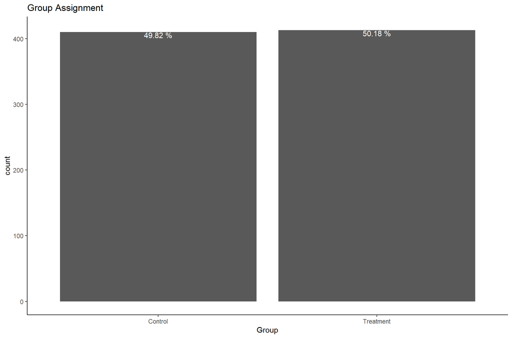

```r
#visualization of group assignment
ggplot(opt %>% drop_na(Group), aes(x = Group)) + geom_bar() + theme_classic() + ggtitle("Group Assignment") +
  stat_count(aes(label = sprintf("%.02f %%", ..count../sum(..count..)*100)), geom = 'text', vjust = 1, color="white") # add percent text
```

The number of participants in each group can be seen more clearly with the below table. The total number of participants was 823, so no participant was not assigned to a group.

```r
#numerical summary of group assignment
kableExtra::kable(opt %>% group_by(Group) %>% summarize("Number of participants" = n()), align = "lc", digits = 4)
```

| Group | Number of participants |
| --- | --- |
| Control | 410 |
| Treatment | 413 |

## 1.2 Birthweight

Compared to group assignment, data on birthweight for 30 participants is missing. As can be seen in the below table and histogram, birthweight is centered around 3200 grams with a range of over 4500 grams. Birthweight also appears to be unimodal and symmetric, while birthweight outliers are skewed towards lower birthweights rather than higher birthweights.

```r
kableExtra::kable(summarize(opt, n_NA = sum(is.na(Birthweight)), mean = mean(Birthweight, na.rm=TRUE), SD = sd(Birthweight, na.rm=TRUE),
              median = median(Birthweight, na.rm=TRUE),
              IQR = quantile(Birthweight, 0.75, na.rm=TRUE)-quantile(Birthweight, 0.25, na.rm=TRUE),
              min = min(Birthweight, na.rm=TRUE),
              max = max(Birthweight, na.rm=TRUE)), digits = 3, "simple"
)
```

| n_NA | mean | SD | median | IQR | min | max |
| --- | --- | --- | --- | --- | --- | --- |
| 30 | 3248.288 | 579.986 | 3280 | 595 | 450 | 5160 |

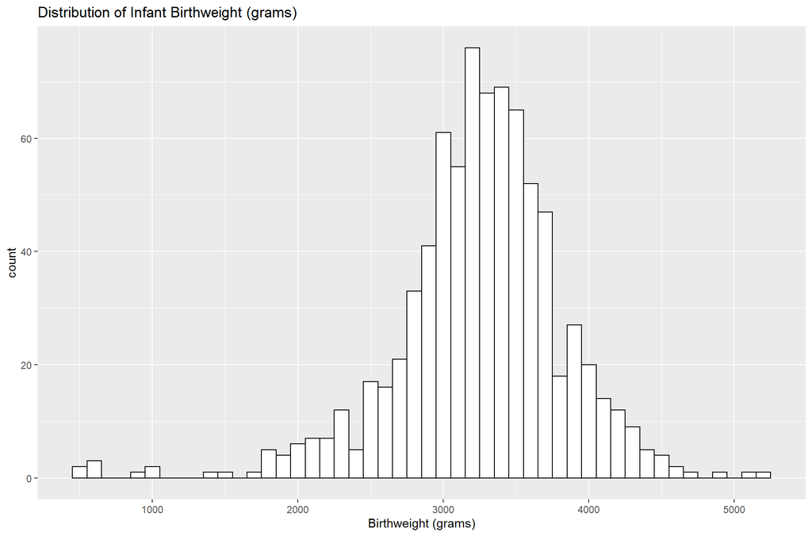

```r
#visualization of infant birthweight
ggplot(opt %>% drop_na(Birthweight), aes(x=Birthweight)) + geom_histogram(binwidth = 100, color="black", fill="white") + # use 100 gram wide bins
  xlab("Birthweight (grams)") + # label the x-axis
  ggtitle("Distribution of Infant Birthweight (grams)") # title the plot
```

## 1.3 Pregnant Individual’s Age at Baseline

Age of pregnant individuals at baseline is centered around 25-26, is unimodal, and right-skewed.

```r
#numerical summary of age of pregnant individual at baseline
kableExtra::kable(summarize(opt, n_NA = sum(is.na(Age)), mean = mean(Age, na.rm=TRUE), SD = sd(Age, na.rm=TRUE),
              median = median(Age, na.rm=TRUE),
              IQR = quantile(Age, 0.75, na.rm=TRUE)-quantile(Age, 0.25, na.rm=TRUE),
              min = min(Age, na.rm=TRUE),
              max = max(Age, na.rm=TRUE)), digits = 3, "simple")
```

| n_NA | mean | SD | median | IQR | min | max |
| --- | --- | --- | --- | --- | --- | --- |
| 0 | 25.978 | 5.566 | 25 | 8 | 16 | 44 |

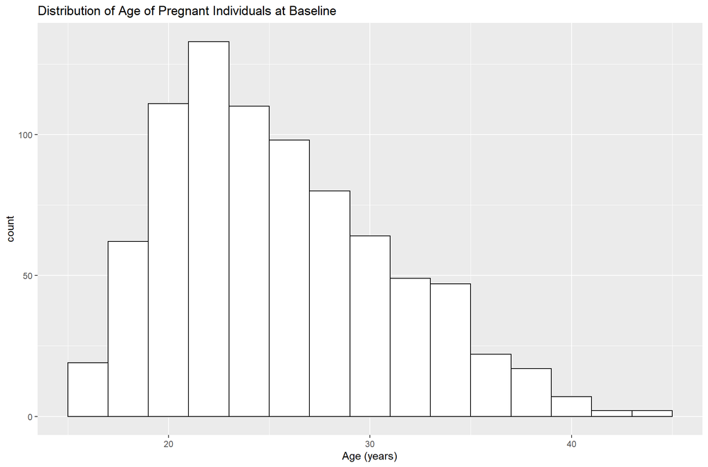

```r
ggplot(opt, aes(x=Age)) + geom_histogram(binwidth = 2, color="black", fill="white") + # use 2 year wide bins
  xlab("Age (years)") + # label the x-axis
  ggtitle("Distribution of Age of Pregnant Individuals at Baseline") # title the plot
```

## 1.4 Preterm Birth

Data on preterm birth is not applicable for 30 participants. 89.66% of participants did not have a preterm birth, while 10.34% of participants did.

```r
#numerical summary of Preterm births #there are NAs
kableExtra::kable(opt %>% group_by(Preterm) %>% summarize("Number of participants" = n()), "pipe")
```

| Preterm | Number of participants |
| --- | --- |
| N | 711 |
| Y | 82 |
| NA | 30 |

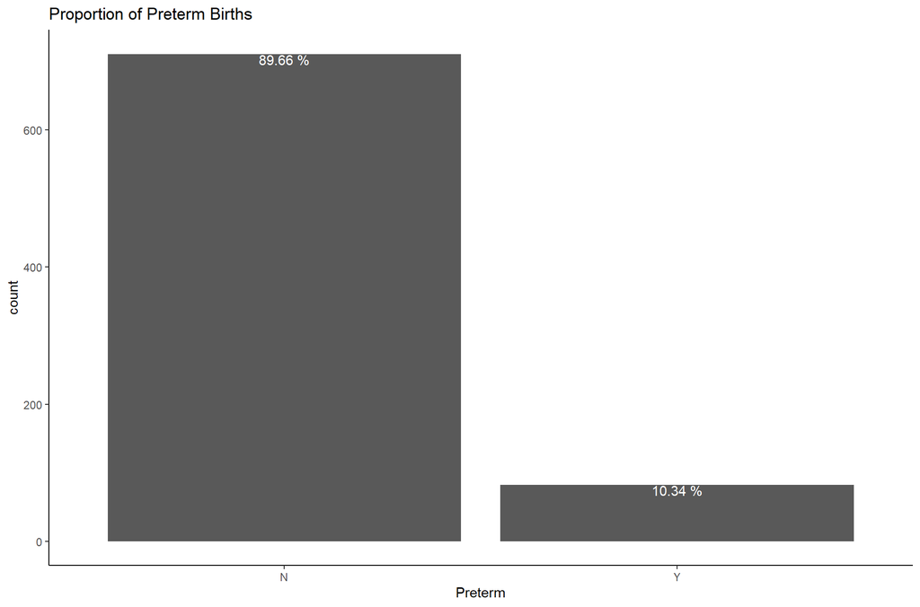

```r
#visualization of pre-term birth
ggplot(opt %>% drop_na(Preterm), aes(x = Preterm)) + geom_bar() + theme_classic() + ggtitle("Proportion of Preterm Births") +
  stat_count(aes(label = sprintf("%.02f %%", ..count../sum(..count..)*100)), geom = 'text', vjust = 1, color="white") # add percent text
```

## 1.5 Extreme Birthweights

The maximum infant birthweight observed was 5160 grams. It’s z-score is ~3.296, which means this observation is ~3.296 standard deviations above the mean birthweight. The minimum infant birthweight was 450 grams. It’s z-score is approximately -4.825, which means this minimum observation is approximately 4.825 standard deviations below the mean birthweight. Both the minimum and maximum observations are very surprising given the sample mean birthweight of ~3248 grams and standard deviation of ~579 grams. That is, under the location and scale parameters of the sample distribution, the maximum and minimum observations had less than a 1% chance of being observed.

Code for finding the maximum, minimum, mean, and standard deviation of birthweight is given below. Code for finding the z-scores is also given below.

```r
#obtain max, min, mean, sd of birthweight. Calculate z score of max and min assuming normal distr w/ sample mean and sd
max_bw = max(opt$Birthweight, na.rm = TRUE)
min_bw = min(opt$Birthweight, na.rm = TRUE)
mean_bw = mean(opt$Birthweight, na.rm = TRUE)
sd_bw = sd(opt$Birthweight, na.rm = TRUE)
zmax = ( max_bw - mean_bw ) / sd_bw
zmin = ( min_bw - mean_bw ) / sd_bw
```

# 2 Two Variable Descriptions

## 2.1 Group and Preterm Status

```r
#numerical summary of preterm status within groups
kableExtra::kable(xtabs(~ Group + Preterm, data=opt) %>% prop.table(margin = 1) %>% round(4), caption = "Preterm birth status by group", "simple")
```

Preterm birth status by group

|  | N | Y |
| --- | --- | --- |
| Control | 0.9028 | 0.0972 |
| Treatment | 0.8905 | 0.1095 |

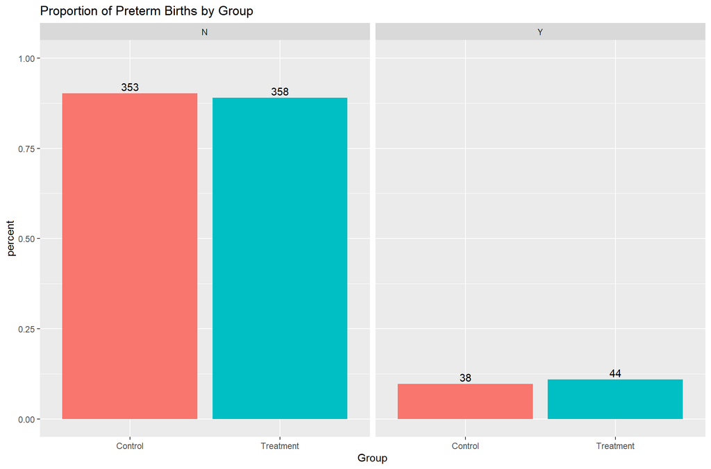

```r
#Visualization of relationship between preterm birth and treatment group
plot_data <- opt %>% drop_na(Group, Preterm) %>%
  group_by(Group, Preterm) %>%
  tally %>%
  mutate(percent = n/sum(n))
ggplot(data = plot_data, aes(x = Group, y = percent)) +
  geom_bar(stat="identity", aes(fill = Group)) +
  theme(legend.position = "none") + # suppress legend
  scale_y_continuous(limits=c(0,1)) + # force y-axis to be 0-1
  facet_wrap(. ~ Preterm) +  # separate by var2
  geom_text(aes(label = n), vjust = -0.3) + # add counts as text
  ggtitle("Proportion of Preterm Births by Group")
```

```r
#calculate difference in proportion of subjects
#with preterm birth between treatment and control group
ctl_pt = nrow(filter(filter(opt, Group == "Control"), Preterm == "Y"))
ctl_nt = nrow(filter(filter(opt, Group == "Control"), Preterm == "N"))
tmt_pt = nrow(filter(filter(opt, Group == "Treatment"), Preterm == "Y"))
tmt_nt = nrow(filter(filter(opt, Group == "Treatment"), Preterm == "N"))
pt_diff = abs(ctl_pt / ctl_nt - tmt_pt / tmt_nt)
na_tmt_pt = summarize(opt %>% filter(Group =="Treatment"), n_NA = sum(is.na(Preterm)))
na_ctl_pt = summarize(opt %>% filter(Group =="Control"), n_NA = sum(is.na(Preterm)))
```

## 2.2 Preterm status and Pregnant Individual’s Age

```r
#numerical summary of preterm birth and age
kableExtra::kable(opt %>% group_by(Preterm) %>%
  summarize(n = n(),
            mean = mean(Age, na.rm=TRUE),
            SD = sd(Age, na.rm=TRUE),
            median = median(Age, na.rm=TRUE),
            IQR = quantile(Age, 0.75, na.rm=TRUE)-quantile(Age, 0.25, na.rm=TRUE),
            min = min(Age, na.rm=TRUE),
            max = max(Age, na.rm=TRUE)), digits = 2, "simple")
```

| Preterm | n | mean | SD | median | IQR | min | max |
| --- | --- | --- | --- | --- | --- | --- | --- |
| N | 711 | 25.82 | 5.49 | 25 | 7.50 | 16 | 44 |
| Y | 82 | 27.55 | 6.10 | 27 | 8.75 | 18 | 44 |
| NA | 30 | 25.43 | 5.22 | 24 | 6.00 | 17 | 39 |

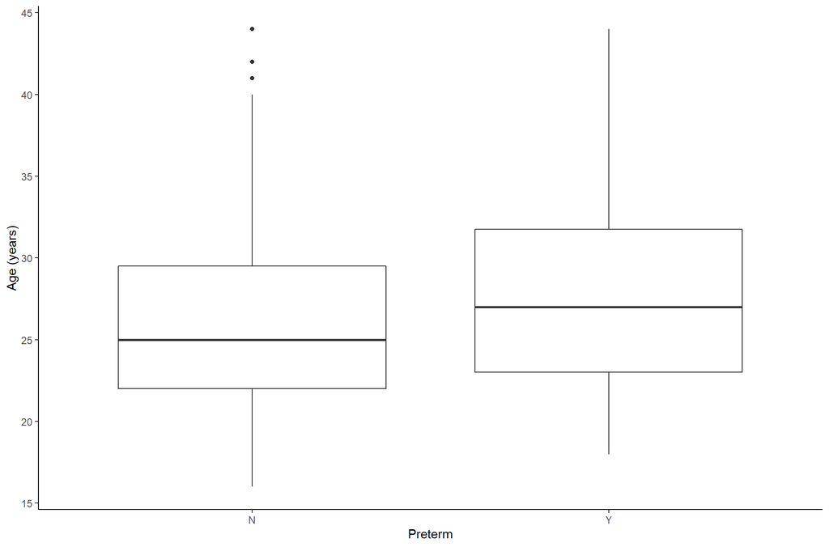

```r
#visualization to examine relationship between
#preterm birth and maternal age
ggplot(opt %>% drop_na(Preterm, Age), aes(y=Age, x=Preterm)) + geom_boxplot() +
  theme_classic() + ylab("Age (years)")
```

```r
#calc difference in mean age between preterm and normal term
mean_age_pt = mean(filter(opt, Preterm == "Y")$Age)
mean_age_nt = mean(filter(opt, Preterm == "N")$Age)
mean_age_term_diff = abs(mean_age_pt - mean_age_nt)
```

## 2.3 Infant Birthweight and Pregnant Individual’s Age

There is an extremely weak positive correlation between infant birthweight and pregnant individual’s age (r = .038). This means that either of these variables accounts for less than 2% of the variance of the other, while greater than 98% of the variance is left unexplained. This is illustrated in the below scatterplot, where a wide and mostly equal range of birthweights is present for every age. Code for calculating the correlation coefficient is also present below.

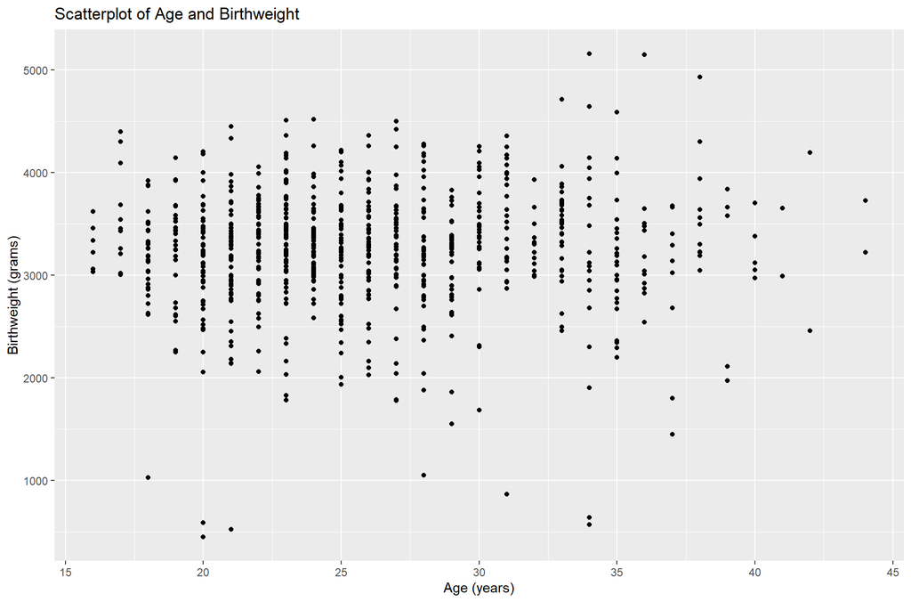

```r
#numerical - birthweight and age correlation
age_bw_cor = cor(opt$Age, opt$Birthweight, use="pairwise.complete.obs")

#visualization - birthweight and age
ggplot(opt %>% drop_na(Birthweight, Age), aes(x=Age, y=Birthweight)) + geom_point() + ylab("Birthweight (grams)") + xlab("Age (years)") + ggtitle("Scatterplot of Age and Birthweight")
```